# Ford GoBike System Data Analysis

## by Ohiri Emeka Emmanuel

## Investigation Overview

> In this investigation, I wanted to see features that may prompt a rider to share a bike during a ride trip. The main features of focus was *'duration_sec'*, *'user_type'*, *'member_gender'*, *'member_birth_year'*. Three columns after been created by feature engineering existing columns were added to the list of main features (*'age'*, *'start_day'*, *'end_day'*)

## Dataset Overview

> The data consisted of individual rides made in a bike-sharing system covering the greater San Francisco Bay area and it is centered on 2019 only. This document explores a dataset containing about 183,000 bike records and 16 features that clearly show details of how bikes are shared amongst riders.

> The dataset after all analysis and feature engineering had 20 columns while maintaining same length of rows.

## Distribution of Trip Duration (secs)

Trip duration_sec was long tailed and not well distributed. Using log scale, when plotted, duration looks modal and skewed to the right. You can see that higher peaks of trip appeared between 500 - 1000k before a steady decline began to occur.

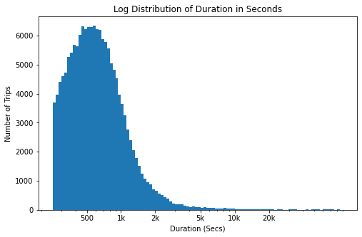

## Distribution of Member_birth_year

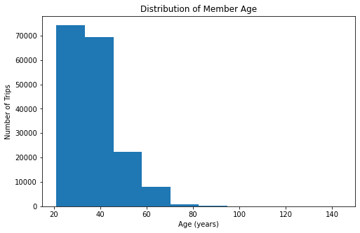

## Distribution of Start_day and End_day

The histogram distribution of start_day had seen thursday having the highest frequency of rides and exact same distribution was seen at the distribution of end_day.

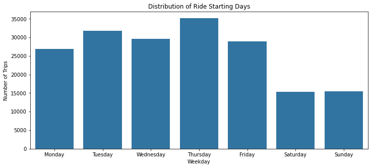

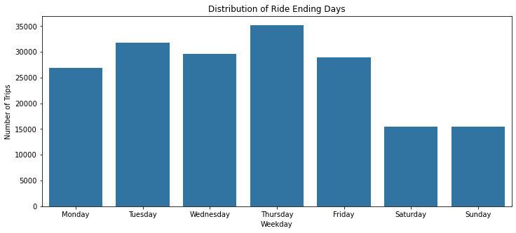

## Correlation Plot of Entire Numeric Columns to Determine Relationship

There is less than 50% correlation between start_station_id and end_station_id while the relationship between member_birth_year and age is highly negetively correlated (100%). There is no correlation between duration_sec and start_station_id nor end_station_id. The relationship between start_station_latitude and end_station_latitude was about 99% (positive correlation. The correlation between start_station_latitude and end_station_longitude was more than 50% negetively correlated (-0.68) and same degree of correlation was seen between end_station_latitude and start_station_longtitude

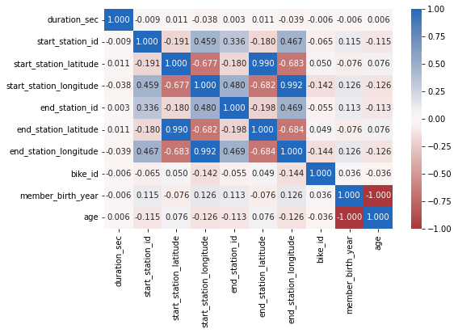

## User_type vs Bike_share_for_all_trip

A plot of user_type and bike_share_for_all_trip was plotted to determine the relationship between both features. It is discovered that subscriber user type emerged highest on riders that shared bikes and also did not share.

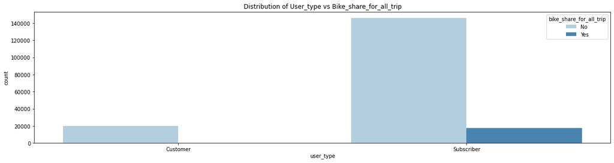

## Member_gender vs Bike_share_for_all_trip

The column of member_gender and bike_share_for_all_trip was plotted against each other to determine the relationship between them. The male gender had highest count when it came down to sharing a bike during the trip and equally topped the chart when options of not sharing a bike was looked at.

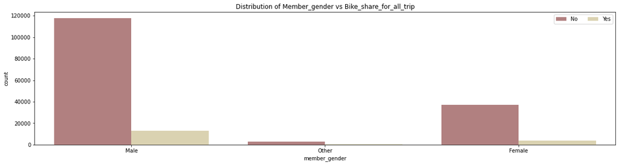

## Member_gender vs User_type

The both features we plotted against each other to determine the relationship of gender on user_type during the trip. Male gender subscribed most more than other gender.

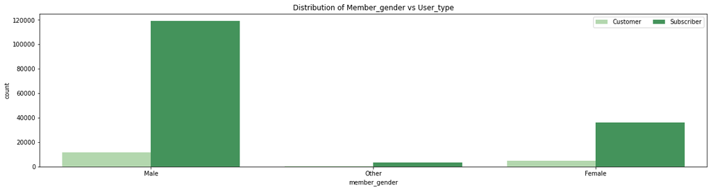

## Duration_sec and Age on User_type

A FacetGrid mapped with scatterplot was plotted having duration_sec and age on user_type using option on *bike_share_for_all_trip == 'Yes'*, confirmed that riders between the age 20 - 30 covered higher durations and more distribution, only few riders in the subscriber user type shared their bikes. The oldest rider age that shared bike in the user category was around 125 years of age.

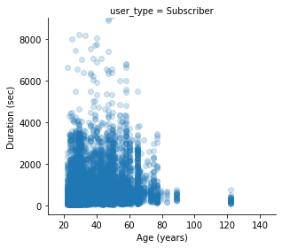

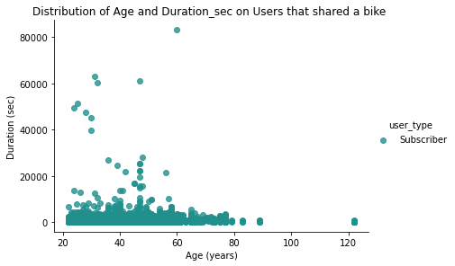

## Duration_sec and Age on Member_gender

A FacetGrid mapped with scatterplot was plotted having duration_sec and age on member_gender using option on *bike_share_for_all_trip == 'Yes'*. Male gender was seen to be well distributed with the male gender having more duration_sec than other gender types. During the exploration stage using countplot, we saw male gender also having high trips on all user types. A female rider covered the most duration_sec on a trip while the oldest rider bein a male.

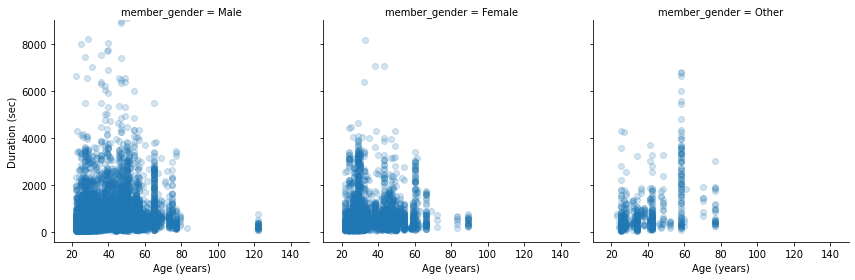

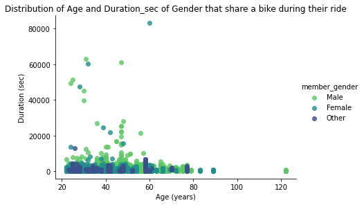

## Duration_sec and Age on Bike_share_for_all_trip

The scatter plot clearly shows that most riders did not share a bike as the yellow colour indicates *0 == 'No' and also, that most older riders equally did not share a bike. It is also evident that less amount of riders shared a bike and thus, why the distribution of the yellow colour (0 == 'No') is more distributed.

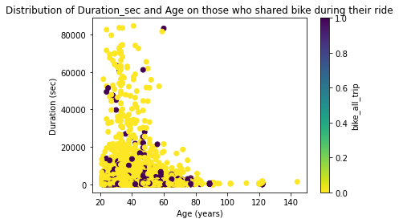